# Genome-wide methylation analysis report

# Genome-wide methylation analysis report

- study: Pleural cfDNAm analysis of malignant.fulladjvariable
- author: Paul Yousefi
- date: 08 October, 2026

## Parameters

```
## $sig.threshold
## [1] 2.121143e-07
##
## $max.plots
## [1] 10
##
## $qq.inflation.method
## [1] "median"
##
## $practical.threshold
## [1] 9.844806e-05
```

## Sample characteristics

For continuous or ordinal variables, the “mean” column provides the mean and the “sd/%” column the standard deviation of the variable. For categorical variables, the “mean” column provides the number of samples with the given “value” and the “sd/%” column the percentage of samples with the given “value”.

| variable | value | mean | sd.. |
| --- | --- | --- | --- |
| malignant |  | 0.5537459 | 0.4979146 |
| female |  | 0.3517915 | 0.478309 |
| age |  | 71.00326 | 12.89006 |
| plate |  | 2.319218 | 1.048991 |
| sv1 |  | -1.992045e-19 | 0.0571662 |
| sv2 |  | -9.380821e-21 | 0.0571662 |
| sv3 |  | 2.40149e-20 | 0.0571662 |
| sv4 |  | -1.409816e-18 | 0.0571662 |
| sv5 |  | -9.229624e-19 | 0.0571662 |
| sv6 |  | -8.895667e-19 | 0.0571662 |
| sv7 |  | 3.33619e-18 | 0.0571662 |
| sv8 |  | 8.317474e-16 | 0.0571662 |
| sv9 |  | 2.231674e-14 | 0.0571662 |
| sv10 |  | 1.244293e-12 | 0.0571662 |

## Covariate associations

### Covariate female

statistics

| var1 | var2 | F | p-value | R | p-value |
| --- | --- | --- | --- | --- | --- |
| malignant | female | 4.934526 | 0.0270593 | 0.1261792 | 0.0270593 |

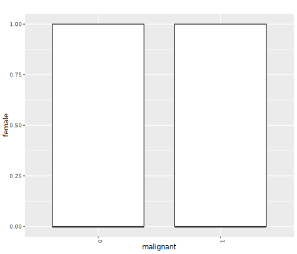

### Covariate age

statistics

| var1 | var2 | F | p-value | R | p-value |
| --- | --- | --- | --- | --- | --- |
| malignant | age | 10.32879 | 0.00145 | 0.1561484 | 0.0061137 |

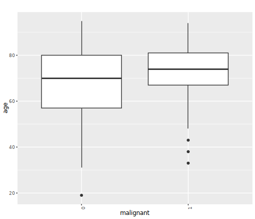

### Covariate plate

statistics

| var1 | var2 | F | p-value | R | p-value |
| --- | --- | --- | --- | --- | --- |
| malignant | plate | 3.601985 | 0.0586547 | -0.1085678 | 0.0574172 |

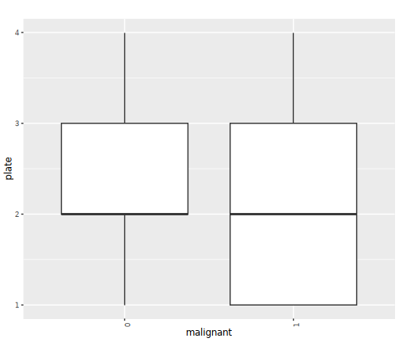

### Covariate sv1

statistics

| var1 | var2 | F | p-value | R | p-value |
| --- | --- | --- | --- | --- | --- |
| malignant | sv1 | 6.816443 | 0.0094785 | 0.1502427 | 0.0083714 |

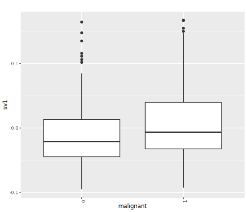

### Covariate sv2

statistics

| var1 | var2 | F | p-value | R | p-value |
| --- | --- | --- | --- | --- | --- |
| malignant | sv2 | 1.286164 | 0.2576466 | 0.0950847 | 0.0963139 |

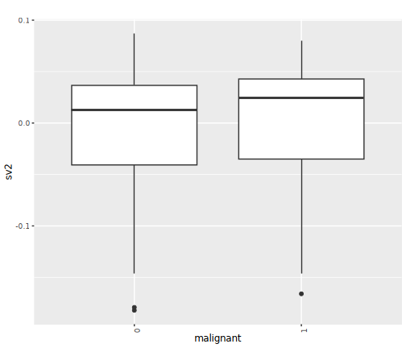

### Covariate sv3

statistics

| var1 | var2 | F | p-value | R | p-value |
| --- | --- | --- | --- | --- | --- |
| malignant | sv3 | 0.0285168 | 0.8660114 | 0.0166361 | 0.7715718 |

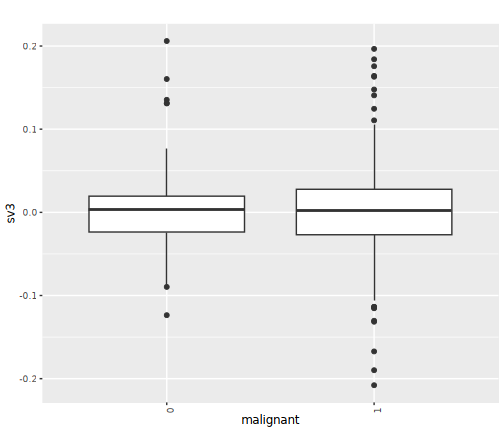

### Covariate sv4

statistics

| var1 | var2 | F | p-value | R | p-value |
| --- | --- | --- | --- | --- | --- |
| malignant | sv4 | 0.0640363 | 0.800397 | -0.0160446 | 0.7794808 |

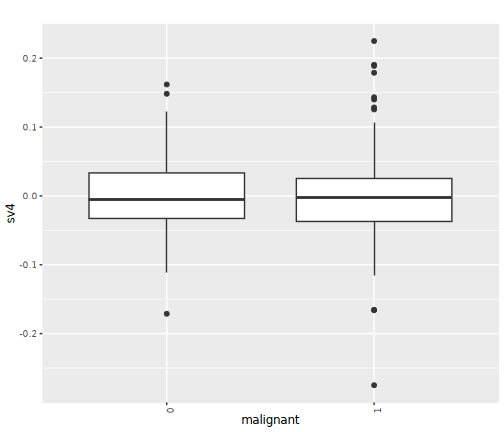

### Covariate sv5

statistics

| var1 | var2 | F | p-value | R | p-value |
| --- | --- | --- | --- | --- | --- |
| malignant | sv5 | 0.0514554 | 0.8207019 | -0.0042145 | 0.9413741 |

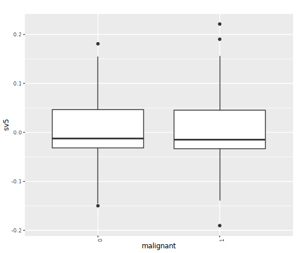

### Covariate sv6

statistics

| var1 | var2 | F | p-value | R | p-value |
| --- | --- | --- | --- | --- | --- |
| malignant | sv6 | 0.1026181 | 0.7489295 | 0.014418 | 0.8013456 |

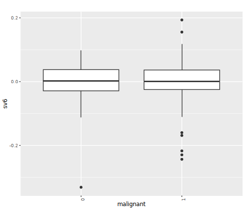

### Covariate sv7

statistics

| var1 | var2 | F | p-value | R | p-value |
| --- | --- | --- | --- | --- | --- |
| malignant | sv7 | 0.8627295 | 0.3537105 | -0.0422927 | 0.4603102 |

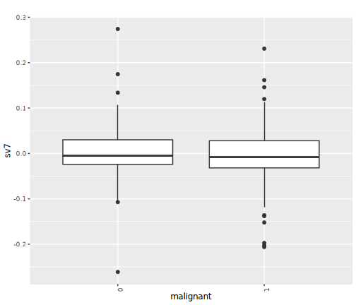

### Covariate sv8

statistics

| var1 | var2 | F | p-value | R | p-value |
| --- | --- | --- | --- | --- | --- |
| malignant | sv8 | 0.690949 | 0.406492 | -0.0580416 | 0.3107367 |

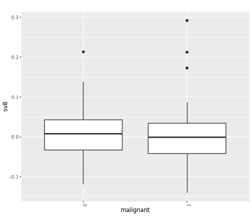

### Covariate sv9

statistics

| var1 | var2 | F | p-value | R | p-value |
| --- | --- | --- | --- | --- | --- |
| malignant | sv9 | 1.257802 | 0.2629497 | -0.0327547 | 0.5675111 |

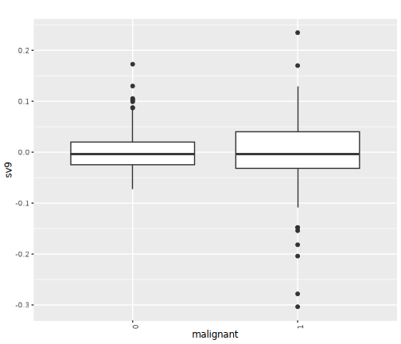

### Covariate sv10

statistics

| var1 | var2 | F | p-value | R | p-value |
| --- | --- | --- | --- | --- | --- |
| malignant | sv10 | 2.817042 | 0.0942924 | -0.0642524 | 0.2617089 |

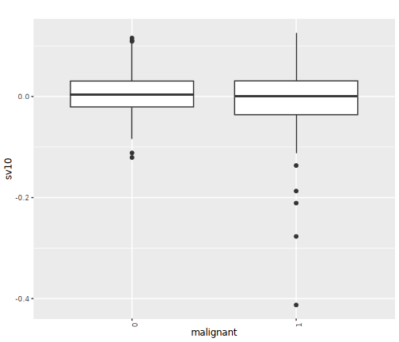

## QQ plots

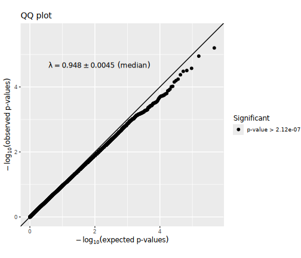

## Manhattan plots

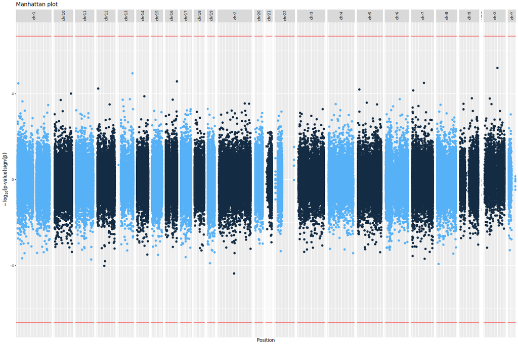

## Significant CpG sites

There were 0 CpG sites with association p-values < 2.1211427 × 10<sup>-7</sup>. These are listed in the file associations.csv.

Below are the 10 CpG sites with association p-values < 9.8448059 × 10<sup>-5</sup> in the regression model.

|  | chromosome | position | estimate | p.value | p.adjust |
| --- | --- | --- | --- | --- | --- |
| cg15034150 | chr7 | 7276930 | 0.0476012 | 7.03e-05 | 1 |
| cg17642208 | chr12 | 54151110 | -0.0289582 | 9.57e-05 | 1 |
| cg27358021 | chrX | 99661597 | 0.0684385 | 6.30e-06 | 1 |
| cg00127989 | chr1 | 5998680 | 0.0408620 | 3.31e-05 | 1 |
| cg11080651 | chr5 | 10445523 | 0.0423250 | 6.36e-05 | 1 |
| cg27038676 | chr16 | 88334272 | 0.0533149 | 2.68e-05 | 1 |
| cg19136366 | chr13 | 108876272 | 0.0337419 | 1.13e-05 | 1 |
| cg19651219 | chr2 | 115419729 | -0.0478473 | 4.22e-05 | 1 |
| cg04549111 | chr7 | 90138040 | 0.0326080 | 3.12e-05 | 1 |
| cg20652042 | chr12 | 6883826 | 0.0332556 | 5.75e-05 | 1 |

Plots of these sites follow, one for each covariate set. “p[lm]” denotes the p-value obtained using a linear model and “p[beta]” the p-value obtained using beta regression.

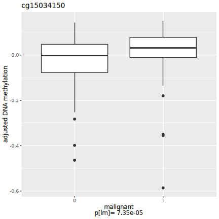

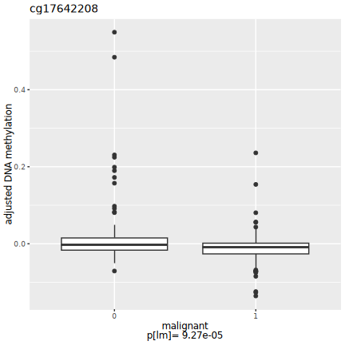

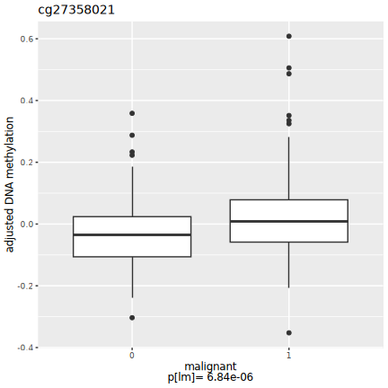

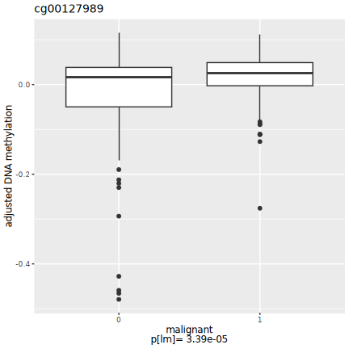

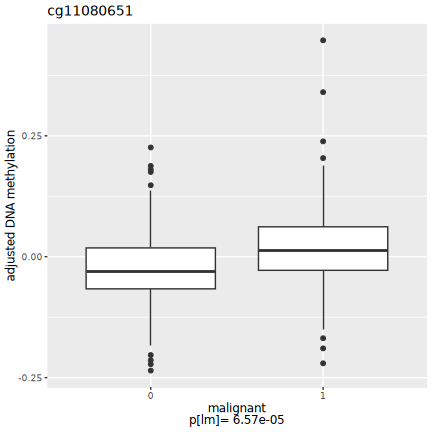

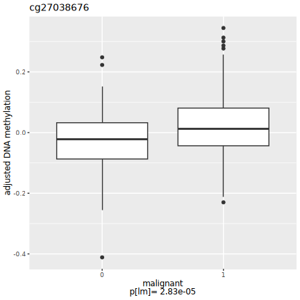

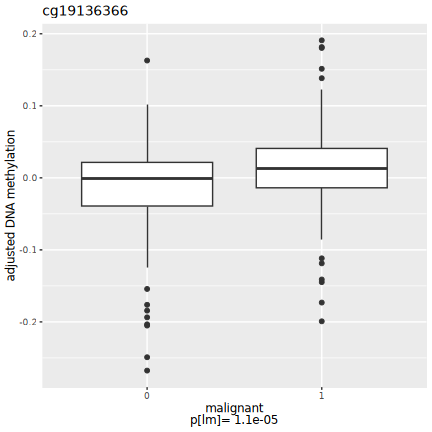

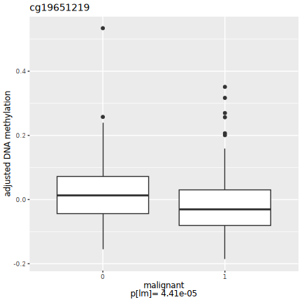

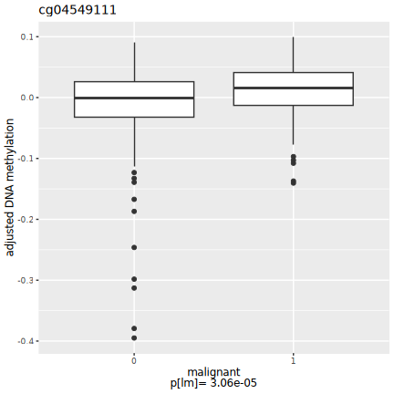

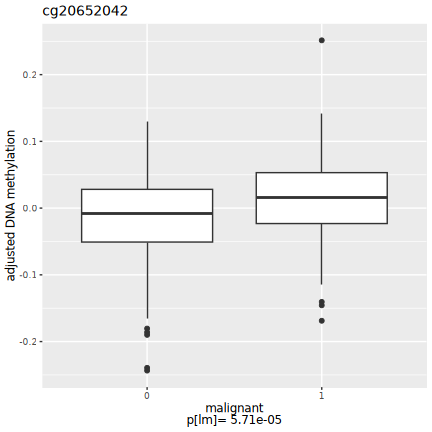

## Selected CpG sites

Number of CpG sites selected: 0.

| chromosome | position | estimate | p.value | p.adjust |
| --- | --- | --- | --- | --- |